# Fundamentos de Análisis de Datos

Noelia Herranz - David Rodríguez

14/1/2023

# 1 Rúbrica de la asignatura

- Uso de herramienta/s de control de versiones (1 punto)
- Definición de objetivos (1 punto)
- Análisis exploratorio inicial (1 punto)
- Detección, tratamiento e imputación de datos faltantes (1 punto)
- Transformaciones de variables cuantitativas (1 punto)
- Procesado de variables cualitativas (1 punto)
- Selección de variables (1 punto)
- Ajuste, interpretación y diagnosis del modelo de regresión lineal múltiple (2 puntos)
- Valoración del profesor (1 punto)

# 2 Definición de objetivos

Disponemos de una tabla obtenida de Kaggle con información relativa a préstamos personales en EE.UU.. En esta tabla tenemos una variedad de campos tanto numéricos como categoricos que nos aportan a nivel de cliente y para un préstamo personal concreto, información previa a la solicitud del préstamo, edad, ingresos, tiempo trabajado de la persona, tipo de interés, importe y finalidad del préstamo,…y una vez finalizados los plazos de pago, se informa sí ha pagado el préstamo o no.

En este trabajo la finalidad es realizar una regresión múltiple y seleccionaremos como variable dependiente el importe de préstamo, como es obvio es una variable numérica.

Es un ejemplo un poco forzado, dado que, en la realidad, el cliente ya sabe la cantidad que solicita y en algunos casos, si la persona es cliente de la entidad que solicita el préstamo puede que la entidad tenga ya límites preconcedidos de préstamos.

Como decíamos queremos realizar un modelo multivariante para poder estimar el importe del préstamo del cliente con la información disponible previa a la solicitud del préstamo, este matiz es importante, ya que habrá variables que no podamos utilizar porque son variables calculadas a posteriori de la solicitud del préstamo que son calculadas en base al importe del préstamo.

Para todos los contrastes de hipóstesis del trabajo estableceremos un alfa de 0,05.

# 3 Librerías

```r
#if (!require(nortest)) {install.packages("nortest")}
#if (!require(moments)) {install.packages("moments")}
#if (!require(corrplot)) {install.packages("corrplot")}
#if (!require(VIM)) {install.packages("VIM")}
#if (!require(bestNormalize)) {install.packages("bestNormalize")}
#if (!require(leaps)) {install.packages("leaps")}
#if (!require(lmtest)) {install.packages("lmtest")}



library(dplyr)
library(tidyverse)
library(kableExtra)
library(ggplot2)
library(cowplot)
library(corrplot)
library(moments)
library(VIM)
library(nortest)
library(bestNormalize)
library(leaps)
library(lmtest)
```

# 4 Análisis exploratorio de datos

Lectura del fichero de datos y de la descripción de las variables:

```r
#Fijamos una semilla para ser el análisis reproducible
set.seed(1)

#setwd("C:/David/Estadística/Master/Analisis de Fundamentos/R/Practica_1/")


#df <- read.csv('~/máster/Practica_1/credit_risk_dataset.csv', header = TRUE)
df <- read.csv('credit_risk_dataset.csv', header = TRUE)
df <- df %>% dplyr::sample_frac(0.4)
head(df)
```

```
##   person_age person_income person_home_ownership person_emp_length
## 1         25         63000              MORTGAGE                 3
## 2         33         50000                  RENT                 3
## 3         23         32000                  RENT                 3
## 4         31        111000              MORTGAGE                 3
## 5         25        225000                  RENT                 9
## 6         28         57936                  RENT                 2
##         loan_intent loan_grade loan_amnt loan_int_rate loan_status
## 1          PERSONAL          C      3000         13.47           0
## 2          PERSONAL          B     10000            NA           0
## 3 DEBTCONSOLIDATION          C      5000         14.79           0
## 4   HOMEIMPROVEMENT          A      5150          6.62           0
## 5         EDUCATION          D     12000         16.49           0
## 6           MEDICAL          D     13650         14.42           1
##   loan_percent_income cb_person_default_on_file cb_person_cred_hist_length
## 1                0.05                         Y                          2
## 2                0.20                         N                          8
## 3                0.16                         N                          2
## 4                0.05                         N                          6
## 5                0.05                         N                          2
## 6                0.24                         N                         10
```

```r
dim(df)
```

```
## [1] 13032    12
```

El dataset consta de 32581 observaciones y 12 variables que se describen a continuación, pero trabajaremos sobre una muestra del 40%, 13.032:

```r
# Nombre y descripción de variables
#descripcion_variables <- read.csv("~/máster/Practica_1/Descripción de variables.csv", header = TRUE,
descripcion_variables <- read.csv("Descripcion_variables.csv", header = TRUE, fileEncoding = "Latin1", check.names = F,sep=";")
descripcion_variables %>%
  kbl() %>%
  kable_styling()
```

| Nombre de variable | Descripción de variable |
| --- | --- |
| person_age | Edad (años) |
| person_income | Ingresos personales |
| person_home_ownership | Relación con la propiedad de la vivienda |
| person_emp_length | Tiempo trabajado (años) |
| loan_intent | Motivo del préstamo |
| loan_grade | Clasificación del prestamo en base al histórico crediticio, la calidad de la garantía y de la cantidad solicitada |
| loan_amnt | Importe del préstamo ($) |
| loan_int_rate | Tasa de interés del préstamo |
| loan_status | Estado del préstamo |
| loan_percent_income | Porcentaje del préstamo sobre los ingresos |
| cb_person_default_on_file | Falta de pago de un préstamo antiguo |
| cb_person_cred_hist_length | Lapso de tiempo desde el anterior préstamo (años) |

Se observa que las variables clasificación del préstamo (loan_grade), estado del préstamo (loan_status) y porcentaje del préstamo sobre los ingresos (loan_percent_income), son variables que se calculan en base al importe del préstamo, nuestra variable que queremos predecir por lo tanto no se podrán utilizar como variables independientes.

Codificación de las variables

```r
str(df)
```

```
## 'data.frame':    13032 obs. of  12 variables:
##  $ person_age                : int  25 33 23 31 25 28 38 25 25 22 ...
##  $ person_income             : int  63000 50000 32000 111000 225000 57936 306000 33000 60000 40000 ...
##  $ person_home_ownership     : chr  "MORTGAGE" "RENT" "RENT" "MORTGAGE" ...
##  $ person_emp_length         : num  3 3 3 3 9 2 9 3 1 5 ...
##  $ loan_intent               : chr  "PERSONAL" "PERSONAL" "DEBTCONSOLIDATION" "HOMEIMPROVEMENT" ...
##  $ loan_grade                : chr  "C" "B" "C" "A" ...
##  $ loan_amnt                 : int  3000 10000 5000 5150 12000 13650 15000 10000 7600 12000 ...
##  $ loan_int_rate             : num  13.47 NA 14.79 6.62 16.49 ...
##  $ loan_status               : int  0 0 0 0 0 1 0 0 0 0 ...
##  $ loan_percent_income       : num  0.05 0.2 0.16 0.05 0.05 0.24 0.05 0.3 0.13 0.3 ...
##  $ cb_person_default_on_file : chr  "Y" "N" "N" "N" ...
##  $ cb_person_cred_hist_length: int  2 8 2 6 2 10 17 4 4 2 ...
```

Se observa que las variables relación con la propiedad (person_home_ownership), motivo del préstamo (loan_intent) y falta de pago de un préstamo antiguo (cb_person_default_on_file) R las considera cadenas, por lo que modificamos el tipo a factor:

```r
df <- df %>%
         mutate(person_home_ownership  = as.factor(person_home_ownership )) %>%
         mutate(loan_intent  = as.factor(loan_intent )) %>%
         mutate(cb_person_default_on_file=as.factor(cb_person_default_on_file))
```

Modificamos el nombre de la variable dependiente por target

```r
df=df %>% rename(target=loan_amnt)
```

Generamos dos dataframe, uno para entrenamiento (train) y otro para validación:

```r
#kk
set.seed(1)

#create ID variable
df$id <- 1:nrow(df)

#Use 70% of dataset as training set and remaining 30% as testing set
train <- df %>% dplyr::sample_frac(0.7)
validacion  <- dplyr::anti_join(df, train, by = 'id')

#Borrar la variable id
train <-subset(train, select= -c(id))
validacion <-subset(validacion, select= -c(id))
```

Tamaño de los dataframe

```r
dim(train)
```

```
## [1] 9122   12
```

```r
dim(validacion)
```

```
## [1] 3910   12
```

Antes de comenzar a analizar las variables definimos unas funciones en R para facilitar el código del análisis.

Aunque hay multiples paquetes con resumenes estadísticos, generamos uno adaptado y así “jugamos” un poco con R. El matiz es que no encontrabamos ninguno que tenga el porcentaje de ceros por variable.

```r
describe_v1 <-function(dataframe,variable) {

  tabla1 <- dataframe %>%

  summarise(
    cases       = format(n(),big.mark = ","),
    min   = format(min({{variable}}, na.rm = T),big.mark = ","),
    p01   = format(quantile({{variable}},c(0.01), na.rm = T ),big.mark = ","),
    p03   = format(quantile({{variable}},c(0.03), na.rm = T ),big.mark = ","),
    p05   = format(quantile({{variable}},c(0.05), na.rm = T ),big.mark = ","),
    p10   = format(quantile({{variable}},c(0.10), na.rm = T ),big.mark = ","),

    mean  = format(round(mean({{variable}}, na.rm=T), digits = 1),big.mark = ","),
    median  = format(round(median({{variable}}, na.rm=T), digits = 1),big.mark = ","),

    p90   = format(quantile({{variable}},c(0.90), na.rm = T ),big.mark = ","),
    p95   = format(quantile({{variable}},c(0.95), na.rm = T ),big.mark = ","),
    p97   = format(quantile({{variable}},c(0.97), na.rm = T ),big.mark = ","),
    p99   = format(quantile({{variable}},c(0.99), na.rm = T ),big.mark = ","),

    max   = format(max({{variable}}, na.rm = T),big.mark = ","),

    )


  return(tabla1)
}
```

```r
describe_v2 <-function(dataframe,variable) {

  tabla2 <- dataframe %>%
  summarise(
    sesgo    = format(round(skewness({{variable}}, na.rm = T), digits = 1),big.mark = ","),
    curtosis    = format(round(kurtosis({{variable}}, na.rm = T), digits = 1),big.mark = ","),
    sd    = format(round(sd({{variable}}, na.rm = T), digits = 1),big.mark = ","),
    missing         = sum(is.na({{variable}}),digits = 1)-1,
    pct_missing = scales::percent(missing / n()) ,
    valor_0     = sum({{variable}} == 0, na.rm = T),
    pct_valor_0 = scales::percent(valor_0 / n())
    )

  return(tabla2)
}
```

```r
grafico_numerico2 <-function(dataframe,variable) {
    mean_vble  = round(mean(dataframe$variable, na.rm=T), digits = 1)
    return(mean_vble)
}
#v=grafico_numerico2(df,loan_amnt)
```

```r
grafico_numerico <-function(dataframe,variable) {

      #mean_vble  = round(mean(dataframe$variable, na.rm=T), digits = 1)

        fill <- "lightblue"
        line <- "darkblue"

      b3 <- ggplot(dataframe, aes({{variable}})) +
              geom_density(fill = fill, colour = line) +
              #geom_vline(xintercept = mean_vble, size = 1, colour = "#FF3721",linetype = "dashed")+
             theme(plot.title = element_text(hjust = 0.5))

      #return(b3)
}
```

```r
grafico_categoricas <-function(dataframe,variable,titulo,eje_y) {

      #mean_vble  = round(mean(dataframe$variable, na.rm=T), digits = 1)

      fill <- "#4271AE"
      line <- "#1F3552"

      b3 <- ggplot(data = dataframe, aes(x = {{variable}})) +
            geom_bar(color = 'darkslategray', fill = 'steelblue') +
            xlab(eje_y) +
            ylab("Cantidades") +
            ggtitle(titulo) +
            coord_flip()+
            geom_text(stat='count',aes(label=..count..), vjust=-0.5, size=3)

      return(b3)
}

#grafico_categoricas(df,loan_grade,s,ss)
```

```r
grafico_categoricas33 <-function(dataframe,variable) {

      b3 <- (ggplot(dataframe, aes({{variable}}, fill={{variable}}))
           + geom_bar()

           + geom_text(
               aes(label=after_stat(..count..)),
               stat='count',
              nudge_x=-0.14,
               nudge_y=0.125,
              vjust=-0.5
           )
          + geom_text(
         aes(label=scales::percent(round((..prop..),2)), group=1),
         stat='count',
         nudge_x=0.14,
         nudge_y=0.125,
         va="middle",
         vjust=0.5,
         accuracy = 1L

         )+
        theme(axis.text.x = element_text(angle = 60, vjust=0.5, size = 7),
        axis.text.y = element_text(angle = 0, vjust=0.5, size = 7),
        panel.grid.minor = element_blank()
    )
      )

      #return(b3)
}
```

```r
grafico_categoricas_biv <-function(dataframe,variable) {


b1=ggplot(dataframe) +
        geom_density(aes(x = loan_amnt, fill = {{variable}}), position = 'stack') +
        xlab("Importe") +
        ylab("Frecuencia") +
        ggtitle("Importe de préstamo") +
        theme_minimal()

      return(b1)
}
```

```r
grafico_categoricas_biv2 <-function(dataframe,variable) {

    p1 <- df %>% select(target, {{variable}}) %>%
      na.omit() %>%
      ggplot(aes(x={{variable}}, y=target, fill={{variable}})) +
      geom_boxplot()+
      theme(axis.text.x = element_blank(),
        axis.ticks.x = element_blank())

    return(p1)
}
```

```r
grafico_categoricas_biv3 <-function(dataframe,variable) {

    b1= ggplot(data = dataframe, aes(x = target, y = {{variable}})) +
      geom_point(aes(color = {{variable}}), size = 1, alpha = 0.7) +
      geom_smooth(aes(color = {{variable}})) +
      facet_grid({{variable}} ~., scales = 'free') +
      xlab('Puntuación') +
      ylab('Puntuación') +
      ggtitle('gggggggggg') +
      theme_minimal()

      return(b1)
}
```

```r
test_normalidad <-function(df_var){

  anderson<-ad.test(df_var)
  cramer<-cvm.test(df_var)
  lillies<-lillie.test(df_var)

  ## Salida a pantalla
 print(anderson)
 print(cramer)
 print(lillies)
 qqnorm(df_var)

}
```

```r
grafico_train_val_num <-function(df1,df2,variable) {

  fill <- "lightblue"
  line <- "darkblue"

  fill2 <- "lavenderblush2"
  line2 <- "darkred"

  ggplot() +
          geom_density(data=df1,aes({{variable}}), fill = fill, colour = line,alpha=0.5) +
          geom_vline( size = 1, colour = "#FF3721",linetype = "dashed")+
         theme(plot.title = element_text(hjust = 0.2))+

          geom_density(data=df2,aes({{variable}}), fill = fill2, colour = line2,alpha=0.5) +
          geom_vline( size = 1, colour = "#FF3721",linetype = "dashed")+
         theme(plot.title = element_text(hjust = 0.2))
}
```

## 4.1 Análisis univariante

### 4.1.1 Variable dependiente (target)

En primer lugar, se realiza un análisis de la variable dependiente (target).

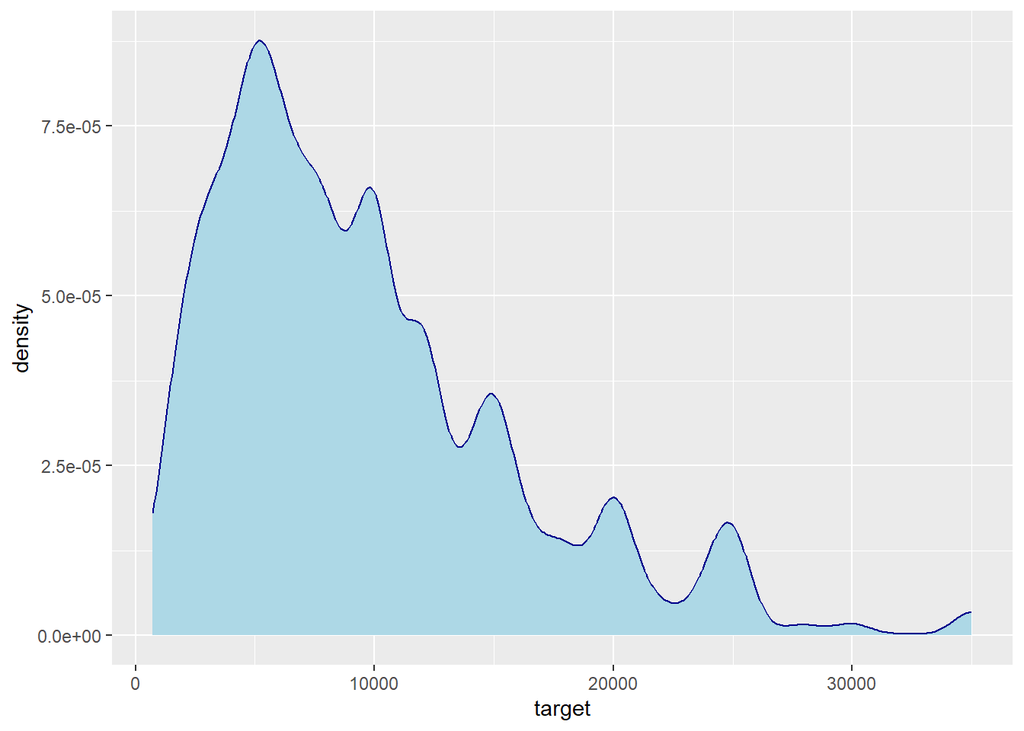

```r
G1=grafico_numerico(train,target)
G1
```

```r
test_normalidad(train$target)
```

```
##
##  Anderson-Darling normality test
##
## data:  df_var
## A = 228.22, p-value < 2.2e-16
##
##
##  Cramer-von Mises normality test
##
## data:  df_var
## W = 36.996, p-value = 7.37e-10
##
##
##  Lilliefors (Kolmogorov-Smirnov) normality test
##
## data:  df_var
## D = 0.1336, p-value < 2.2e-16
```

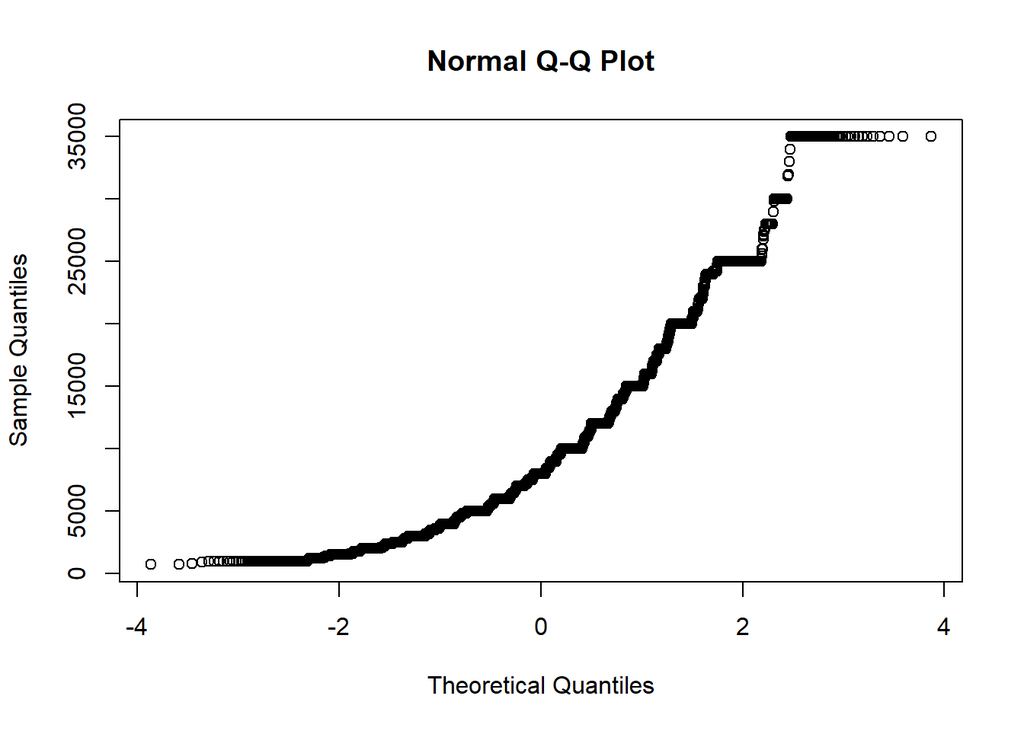

```r
des1=describe_v1(train,target)

  des1 %>%
  kbl() %>%
  kable_styling()
```

| cases | min | p01 | p03 | p05 | p10 | mean | median | p90 | p95 | p97 | p99 | max |
| --- | --- | --- | --- | --- | --- | --- | --- | --- | --- | --- | --- | --- |
| 9,122 | 725 | 1,000 | 1,600 | 2,000 | 3,000 | 9,599.3 | 8,000 | 19,545 | 24,000 | 25,000 | 30,000 | 35,000 |

```r
des2=describe_v2(train,target)

  des2 %>%
  kbl() %>%
  kable_styling()
```

| sesgo | curtosis | sd | missing | pct_missing | valor_0 | pct_valor_0 |
| --- | --- | --- | --- | --- | --- | --- |
| 1.2 | 4.4 | 6,384.6 | 0 | 0% | 0 | 0% |

Se aprecia que no es una variable normal y tendremos que hacer una transformación. Se aprecian picos en las cifras de múltiplos de 5.000

### 4.1.2 Variables independientes numéricas

**Edad (años) (person_age)**

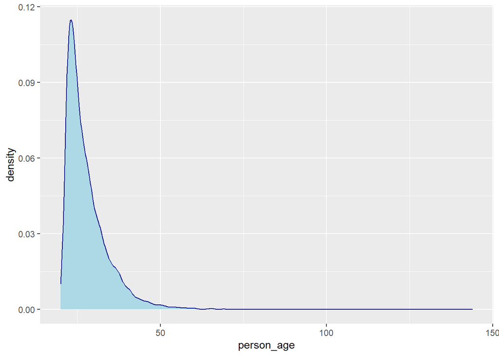

```r
G2=grafico_numerico(train,person_age)
G2
```

```r
test_normalidad(train$person_age)
```

```
##
##  Anderson-Darling normality test
##
## data:  df_var
## A = 408.38, p-value < 2.2e-16
##
##
##  Cramer-von Mises normality test
##
## data:  df_var
## W = 70.414, p-value = 7.37e-10
##
##
##  Lilliefors (Kolmogorov-Smirnov) normality test
##
## data:  df_var
## D = 0.15718, p-value < 2.2e-16
```

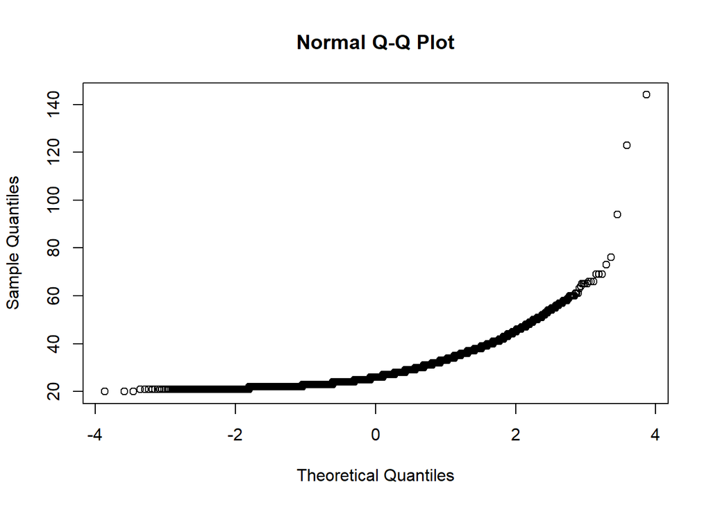

```r
des1=describe_v1(train,person_age)

  des1 %>%
  kbl() %>%
  kable_styling()
```

| cases | min | p01 | p03 | p05 | p10 | mean | median | p90 | p95 | p97 | p99 | max |
| --- | --- | --- | --- | --- | --- | --- | --- | --- | --- | --- | --- | --- |
| 9,122 | 20 | 21 | 21 | 22 | 22 | 27.8 | 26 | 36 | 40 | 43 | 51 | 144 |

```r
des2=describe_v2(train,person_age)

  des2 %>%
  kbl() %>%
  kable_styling()
```

| sesgo | curtosis | sd | missing | pct_missing | valor_0 | pct_valor_0 |
| --- | --- | --- | --- | --- | --- | --- |
| 2.8 | 24.2 | 6.5 | 0 | 0% | 0 | 0% |

Normalmente las políticas de las entidades bancarias restringen los préstamos personales a paritr de una edad, algo lógico para garantizarse que se lo van a pagar. Normalmente esa edad ronda entre los 70 y 75 años, siempre puede haber excepciones. Para nuestro caso consideramos que son datos erróneos y vamos a eliminarlos; también se podría barajar la opción de declararlos como valores missing y luego hacer una imputación de la media, pero dado que tenemos una muestra de información suficiente, se toma la decisión de eliminarlos.

```r
train %>% filter( person_age>75) %>%
        kbl() %>%
        kable_styling()
```

| person_age | person_income | person_home_ownership | person_emp_length | loan_intent | loan_grade | target | loan_int_rate | loan_status | loan_percent_income | cb_person_default_on_file | cb_person_cred_hist_length |
| --- | --- | --- | --- | --- | --- | --- | --- | --- | --- | --- | --- |
| 123 | 78000 | RENT | 7 | VENTURE | B | 20000 | NA | 0 | 0.26 | N | 4 |
| 76 | 75000 | RENT | 23 | MEDICAL | A | 15000 | 8.94 | 0 | 0.20 | N | 25 |
| 144 | 6000000 | MORTGAGE | 12 | PERSONAL | C | 5000 | 12.73 | 0 | 0.00 | N | 25 |
| 94 | 24000 | RENT | 1 | MEDICAL | C | 6500 | NA | 0 | 0.27 | N | 27 |

Se aprecia que no es una variable normal y tendremos que hacer una transformación.

**Ingresos personales (person_income)**

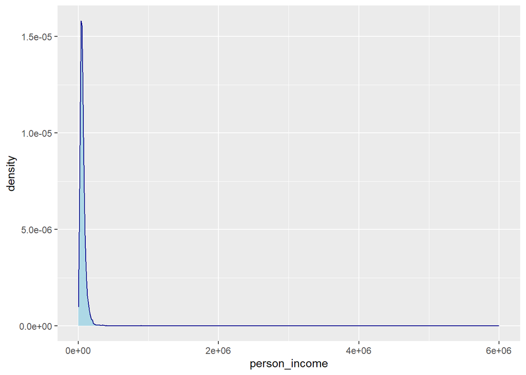

```r
G3=grafico_numerico(train,person_income)
G3
```

```r
des1=describe_v1(train,person_income)

  des1 %>%
  kbl() %>%
  kable_styling()
```

| cases | min | p01 | p03 | p05 | p10 | mean | median | p90 | p95 | p97 | p99 | max |
| --- | --- | --- | --- | --- | --- | --- | --- | --- | --- | --- | --- | --- |
| 9,122 | 4,000 | 13,200 | 19,200 | 22,800 | 28,095.1 | 66,679.3 | 55,000 | 110,000 | 138,000 | 160,000 | 225,000 | 6,000,000 |

```r
des2=describe_v2(train,person_income)

  des2 %>%
  kbl() %>%
  kable_styling()
```

| sesgo | curtosis | sd | missing | pct_missing | valor_0 | pct_valor_0 |
| --- | --- | --- | --- | --- | --- | --- |
| 42.9 | 2,899.4 | 83,048.1 | 0 | 0% | 0 | 0% |

```r
test_normalidad(train$person_income)
```

```
##
##  Anderson-Darling normality test
##
## data:  df_var
## A = 1190.4, p-value < 2.2e-16
##
##
##  Cramer-von Mises normality test
##
## data:  df_var
## W = 218.13, p-value = 7.37e-10
##
##
##  Lilliefors (Kolmogorov-Smirnov) normality test
##
## data:  df_var
## D = 0.25652, p-value < 2.2e-16
```

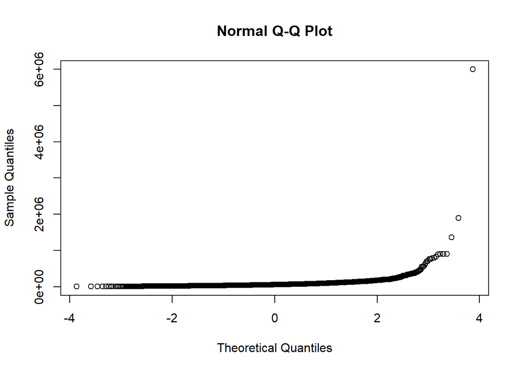

Vemos que hay muchos casos con ingresos altos en la cola derecha, lo que hará que si no los corregimos y entra esta variable en el modelo son candidatos a ser puntos influyentes.

```r
train %>% filter( person_income>600000) %>%
        kbl() %>%
        kable_styling()
```

| person_age | person_income | person_home_ownership | person_emp_length | loan_intent | loan_grade | target | loan_int_rate | loan_status | loan_percent_income | cb_person_default_on_file | cb_person_cred_hist_length |
| --- | --- | --- | --- | --- | --- | --- | --- | --- | --- | --- | --- |
| 35 | 762000 | OWN | 8 | MEDICAL | A | 10000 | 8.94 | 0 | 0.01 | N | 8 |
| 43 | 780000 | MORTGAGE | 2 | HOMEIMPROVEMENT | A | 1000 | 8.94 | 0 | 0.00 | N | 11 |
| 60 | 1900000 | MORTGAGE | 5 | PERSONAL | A | 1500 | NA | 0 | 0.00 | N | 21 |
| 35 | 762000 | OWN | 8 | MEDICAL | A | 10000 | 8.94 | 0 | 0.01 | N | 10 |
| 32 | 703800 | RENT | 14 | MEDICAL | D | 12000 | 15.33 | 1 | 0.01 | Y | 9 |
| 37 | 900000 | MORTGAGE | 5 | PERSONAL | C | 25000 | 12.87 | 0 | 0.03 | Y | 13 |
| 39 | 708000 | MORTGAGE | 14 | DEBTCONSOLIDATION | B | 25000 | 12.18 | 0 | 0.04 | N | 12 |
| 36 | 828000 | MORTGAGE | 3 | HOMEIMPROVEMENT | B | 4200 | NA | 0 | 0.01 | N | 16 |
| 35 | 648000 | MORTGAGE | 6 | PERSONAL | E | 10000 | 17.19 | 1 | 0.02 | Y | 8 |
| 37 | 800000 | MORTGAGE | 10 | DEBTCONSOLIDATION | B | 15000 | 11.36 | 0 | 0.02 | N | 17 |
| 47 | 1362000 | MORTGAGE | 9 | VENTURE | A | 6600 | 7.74 | 0 | 0.00 | N | 17 |
| 28 | 604000 | MORTGAGE | 12 | PERSONAL | B | 25000 | 9.01 | 1 | 0.04 | N | 9 |
| 144 | 6000000 | MORTGAGE | 12 | PERSONAL | C | 5000 | 12.73 | 0 | 0.00 | N | 25 |
| 58 | 900000 | RENT | 18 | DEBTCONSOLIDATION | C | 19600 | 13.98 | 0 | 0.02 | N | 28 |
| 42 | 889000 | RENT | 13 | EDUCATION | A | 20000 | NA | 0 | 0.02 | N | 17 |
| 36 | 900000 | MORTGAGE | 8 | PERSONAL | B | 6000 | NA | 0 | 0.01 | N | 12 |

Se aprecia que no es una variable normal y tendremos que hacer una transformación. También que hay un registro con una ingreso descomunal y que tiene una edad errónea, se eliminará el registro.

**Tiempo trabajado (person_emp_length)**

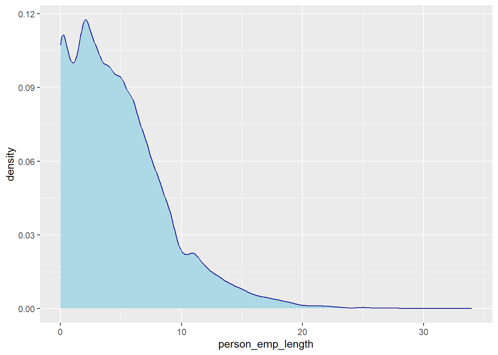

```r
G4=grafico_numerico(train,person_emp_length)
G4
```

```r
# Test de normalidad
test_normalidad(train$person_emp_length)
```

```
##
##  Anderson-Darling normality test
##
## data:  df_var
## A = 194.7, p-value < 2.2e-16
##
##
##  Cramer-von Mises normality test
##
## data:  df_var
## W = 29.599, p-value = 7.37e-10
##
##
##  Lilliefors (Kolmogorov-Smirnov) normality test
##
## data:  df_var
## D = 0.12127, p-value < 2.2e-16
```

```r
des1=describe_v1(train,person_emp_length)

  des1 %>%
  kbl() %>%
  kable_styling()
```

| cases | min | p01 | p03 | p05 | p10 | mean | median | p90 | p95 | p97 | p99 | max |
| --- | --- | --- | --- | --- | --- | --- | --- | --- | --- | --- | --- | --- |
| 9,122 | 0 | 0 | 0 | 0 | 0 | 4.8 | 4 | 10 | 13 | 14 | 18 | 34 |

```r
des2=describe_v2(train,person_emp_length)

  des2 %>%
  kbl() %>%
  kable_styling()
```

| sesgo | curtosis | sd | missing | pct_missing | valor_0 | pct_valor_0 |
| --- | --- | --- | --- | --- | --- | --- |
| 1.3 | 5.6 | 4.1 | 266 | 3% | 1149 | 13% |

Se aprecia que no es una variable normal y tendremos que hacer una transformación.

**Tasa de interés (loan_int_rate)**

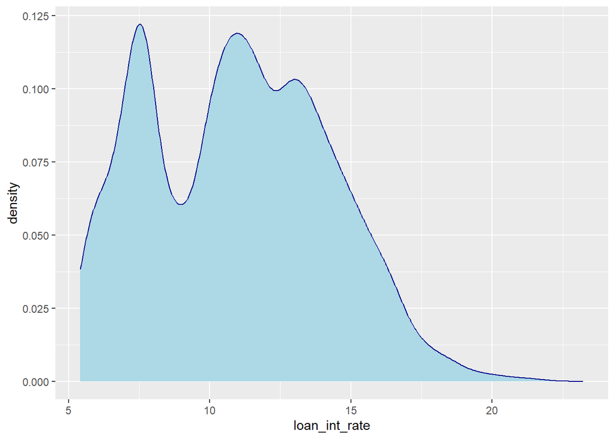

```r
G5=grafico_numerico(train,loan_int_rate)
G5
```

```r
# Test de normalidad
test_normalidad(train$person_emp_length)
```

```
##
##  Anderson-Darling normality test
##
## data:  df_var
## A = 194.7, p-value < 2.2e-16
##
##
##  Cramer-von Mises normality test
##
## data:  df_var
## W = 29.599, p-value = 7.37e-10
##
##
##  Lilliefors (Kolmogorov-Smirnov) normality test
##
## data:  df_var
## D = 0.12127, p-value < 2.2e-16
```

```r
des1=describe_v1(train, loan_int_rate)

  des1 %>%
  kbl() %>%
  kable_styling()
```

| cases | min | p01 | p03 | p05 | p10 | mean | median | p90 | p95 | p97 | p99 | max |
| --- | --- | --- | --- | --- | --- | --- | --- | --- | --- | --- | --- | --- |
| 9,122 | 5.42 | 5.42 | 5.79 | 6.03 | 6.91 | 11 | 11 | 15.27 | 16.32 | 16.89 | 18.39 | 23.22 |

```r
des2=describe_v2(train,loan_int_rate)

  des2 %>%
  kbl() %>%
  kable_styling()
```

| sesgo | curtosis | sd | missing | pct_missing | valor_0 | pct_valor_0 |
| --- | --- | --- | --- | --- | --- | --- |
| 0.2 | 2.4 | 3.2 | 876 | 10% | 0 | 0% |

**Lapso de tiempo desde el anterior préstamo (cb_person_cred_hist_length)**

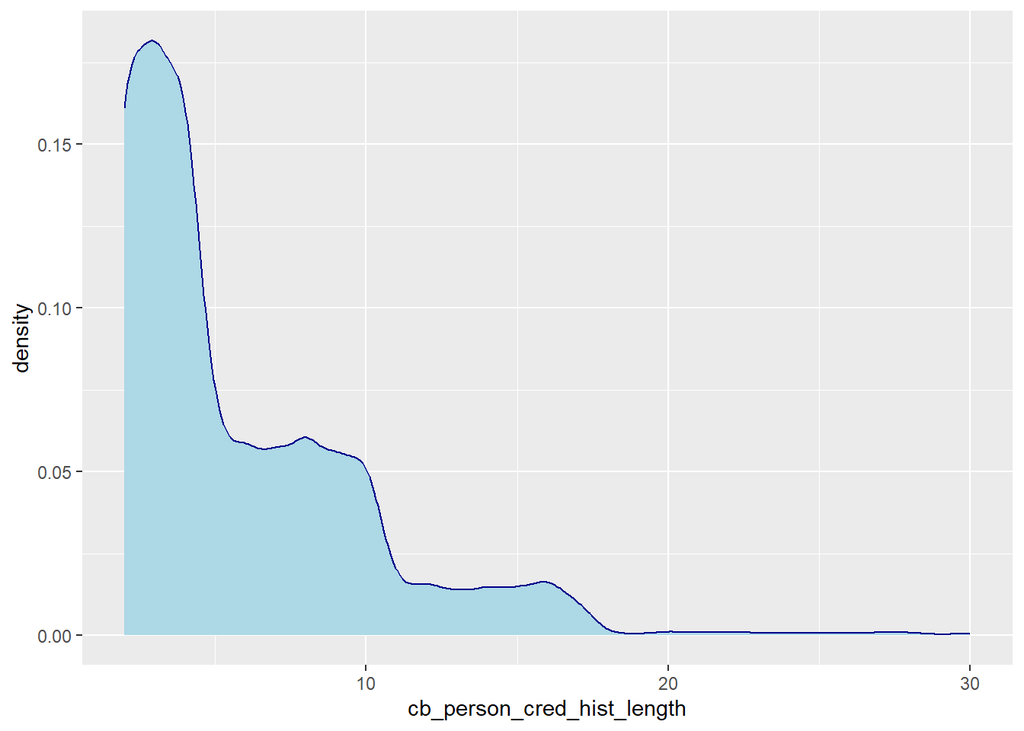

```r
G6=grafico_numerico(train,cb_person_cred_hist_length)
G6
```

```r
# Test de normalidad
test_normalidad(train$person_emp_length)
```

```
##
##  Anderson-Darling normality test
##
## data:  df_var
## A = 194.7, p-value < 2.2e-16
##
##
##  Cramer-von Mises normality test
##
## data:  df_var
## W = 29.599, p-value = 7.37e-10
##
##
##  Lilliefors (Kolmogorov-Smirnov) normality test
##
## data:  df_var
## D = 0.12127, p-value < 2.2e-16
```

```r
des1=describe_v1(train,cb_person_cred_hist_length)

  des1 %>%
  kbl() %>%
  kable_styling()
```

| cases | min | p01 | p03 | p05 | p10 | mean | median | p90 | p95 | p97 | p99 | max |
| --- | --- | --- | --- | --- | --- | --- | --- | --- | --- | --- | --- | --- |
| 9,122 | 2 | 2 | 2 | 2 | 2 | 5.9 | 4 | 11 | 15 | 16 | 18 | 30 |

```r
des2=describe_v2(train,cb_person_cred_hist_length)

  des2 %>%
  kbl() %>%
  kable_styling()
```

| sesgo | curtosis | sd | missing | pct_missing | valor_0 | pct_valor_0 |
| --- | --- | --- | --- | --- | --- | --- |
| 1.7 | 6.7 | 4.1 | 0 | 0% | 0 | 0% |

Esta variable está escalonada, por lo que se discretiza.

### 4.1.3 Variables categóricas

**Relación con la propiedad de la vivienda (person_home_ownership)**

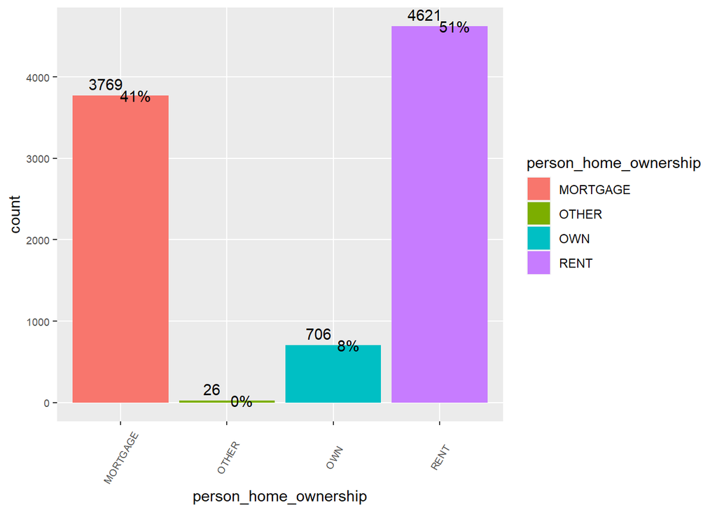

```r
a2=grafico_categoricas33(train,person_home_ownership)
a2
```

El valor de la categoría OTHER tiene muy pocos caso por lo que se le asignará el valor más frecuente RENT.

**Motivo del préstamo (loan_intent)**

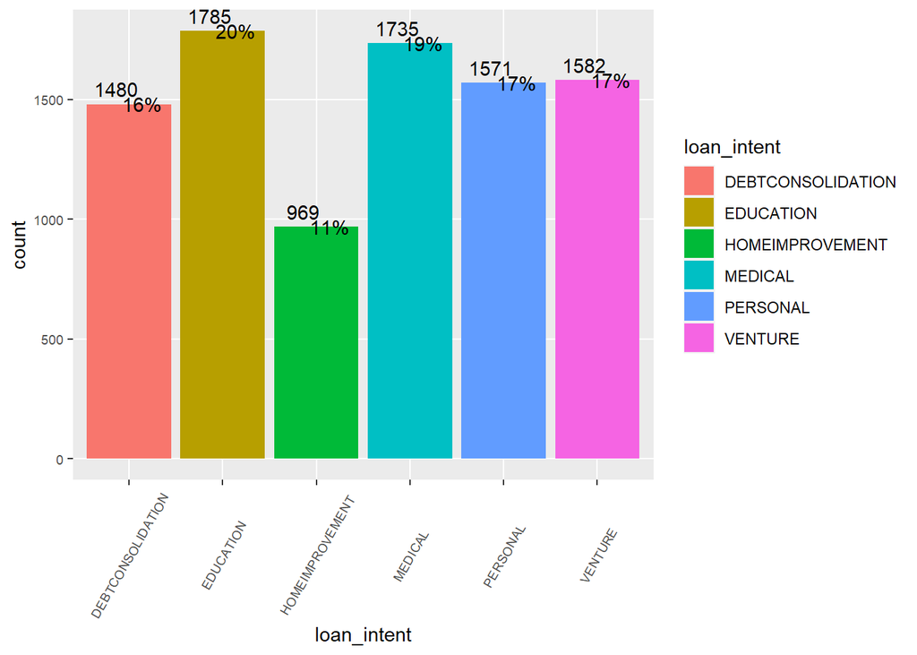

```r
a3=grafico_categoricas33(train,loan_intent)
a3
```

**Falta de pago de un préstamo antiguo (cb_person_default_on_file)**

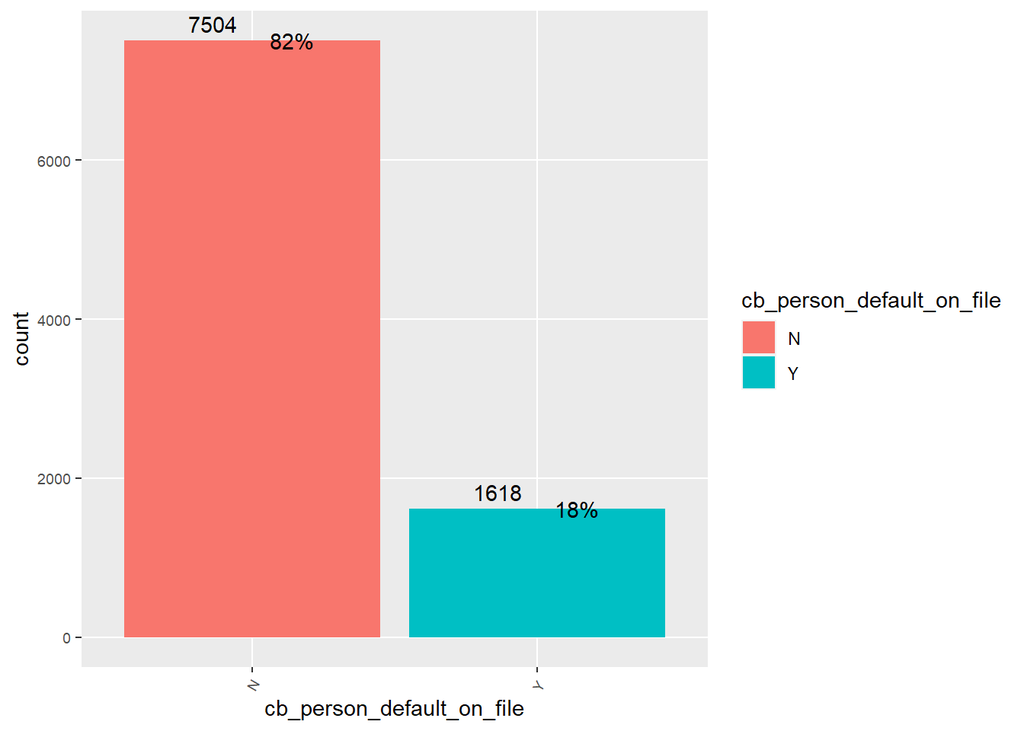

```r
a4=grafico_categoricas33(train,cb_person_default_on_file)
a4
```

## 4.2 Análisis bivariable

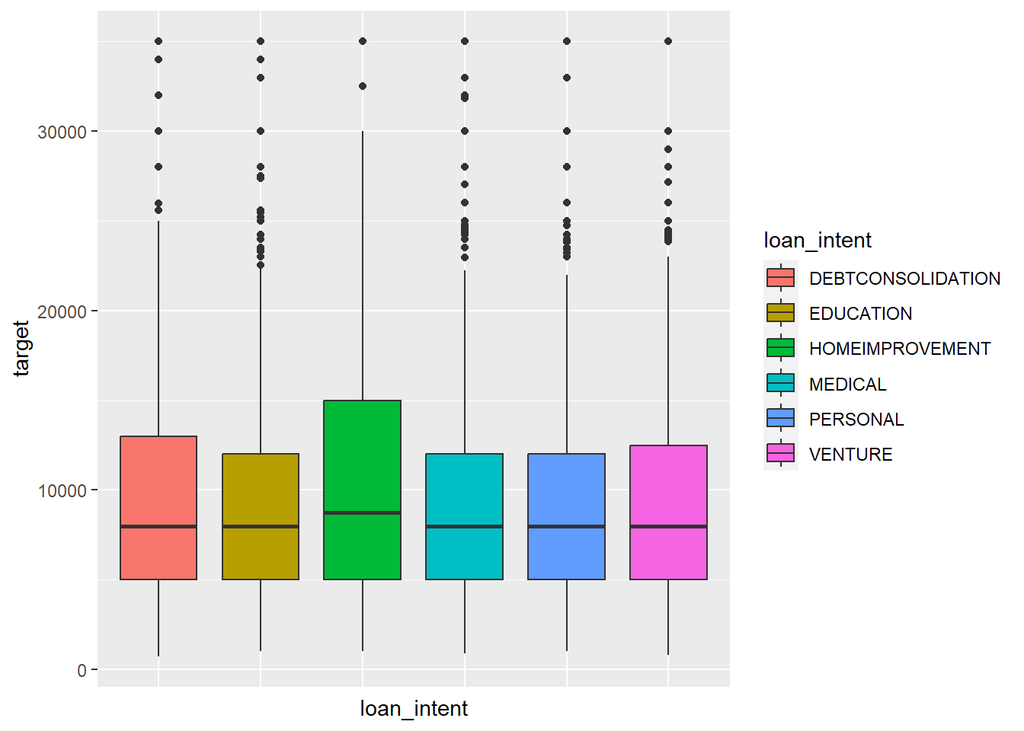

```r
grafico_categoricas_biv2(train, loan_intent)
```

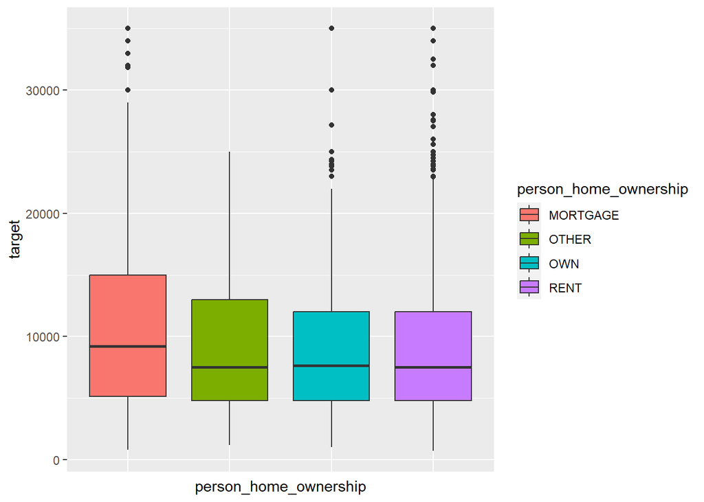

```r
grafico_categoricas_biv2(train, person_home_ownership)
```

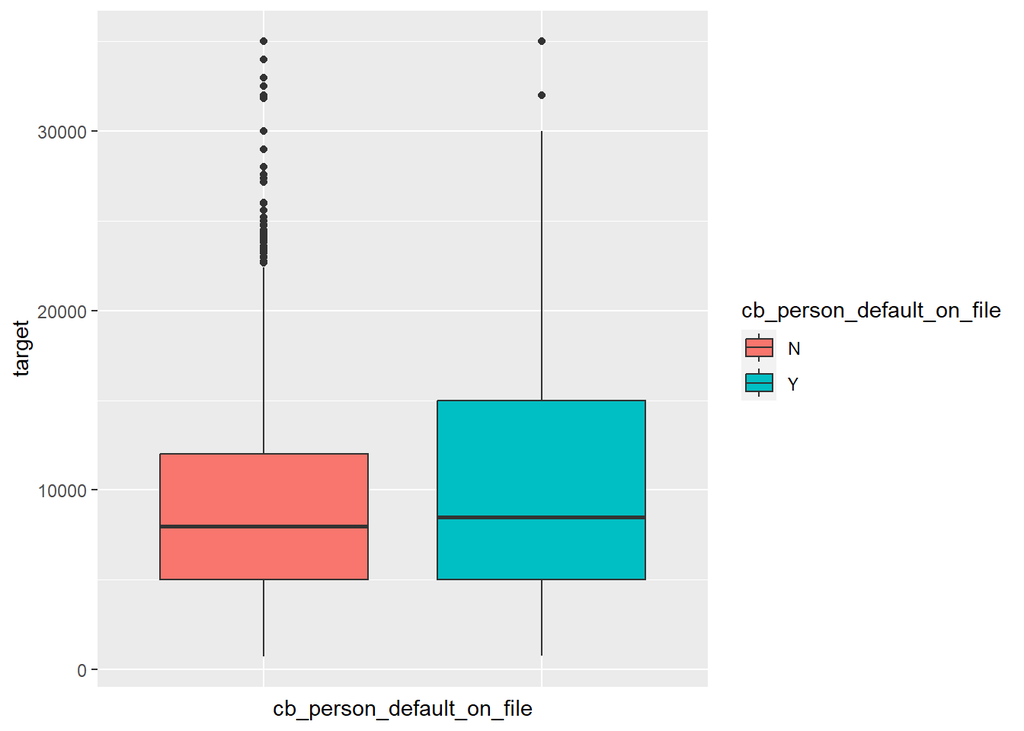

```r
grafico_categoricas_biv2(train,cb_person_default_on_file)
```

Scatter plot entre la variable dependiente, target y las independientes numéricas para ver relaciones entre ellas:

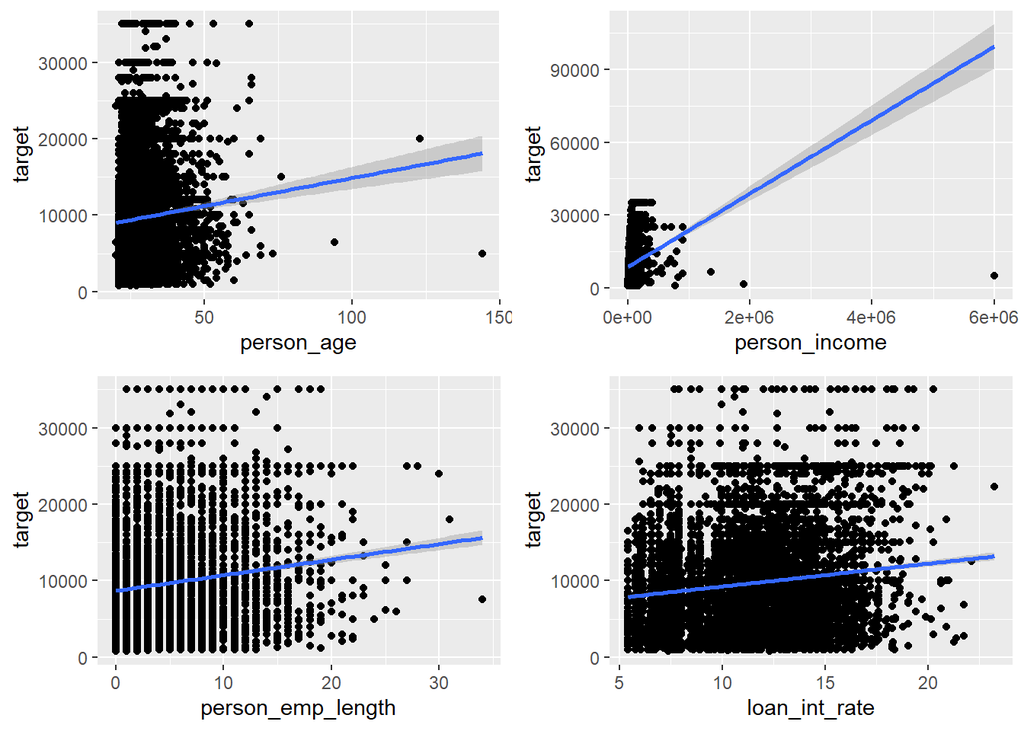

```r
bi1=ggplot(train, aes(x=person_age, y=target)) +
  geom_point() +
  stat_smooth(method=lm)

bi2=ggplot(train, aes(x=person_income, y=target)) +
  geom_point() +
  stat_smooth(method=lm)

bi3=ggplot(train, aes(x=person_emp_length, y=target)) +
  geom_point() +
  stat_smooth(method=lm)

bi4=ggplot(train, aes(x=loan_int_rate, y=target)) +
  geom_point() +
  stat_smooth(method=lm)

plot_grid(bi1, bi2,bi3,bi4)
```

## 4.3 Depuración de EDA

A coninutación, se procede a realizar la depuración que hemos visto en el EDA:

Comentamos de eliminar el registro erróneo, que tiene unos ingresos por persona de 6.000.000 y 144 años y este registro está incluido en el filtro de de eliminar registros mayores de 75 años:

```r
dim(train)
```

```
## [1] 9122   12
```

```r
train <- train %>% filter(person_age<=75)
dim(train)
```

```
## [1] 9118   12
```

Para las variables numéricas imputaremos los valores superiores al percentil 99 con dicho percentil:

```r
#Mejora....con una función si da tiempo o incluso dentro de un mismo train <- train %>%
train <- train %>%
  mutate(target= ifelse(target>=quantile(train$target,0.99),quantile(train$target,0.99), target))

train <- train %>%
  mutate(person_income= ifelse(person_income>=quantile(train$person_income,0.99, na.rm = T), quantile(train$person_income,0.99, na.rm = T), person_income))

train <- train %>%
  mutate(person_emp_length= ifelse(person_emp_length>=quantile(train$person_emp_length,0.99, na.rm = T) ,quantile(train$person_emp_length,0.99, na.rm = T), person_emp_length))

train <- train %>%
  mutate(loan_int_rate= ifelse(loan_int_rate>quantile(train$loan_int_rate,0.99, na.rm = T), quantile(train$loan_int_rate,0.99, na.rm = T), loan_int_rate))

train <- train %>%
  mutate(loan_int_rate= ifelse(loan_int_rate>quantile(train$loan_int_rate,0.99, na.rm = T), quantile(train$loan_int_rate,0.99, na.rm = T), loan_int_rate))

train <- train %>%
  mutate(person_age= ifelse(person_age>quantile(train$person_age,0.99, na.rm = T), quantile(train$person_age,0.99, na.rm = T), person_age))
```

Para la variable categórica relación con la casa (person_home_ownership) la categoría OTHER tiene muy pocos casos y le asignamos el valor más frecuente, en este caso RENT.

```r
table(train$person_home_ownership)
```

```
##
## MORTGAGE    OTHER      OWN     RENT
##     3768       26      706     4618
```

```r
train$person_home_ownership[train$person_home_ownership=="OTHER"] <-"RENT"
table(train$person_home_ownership)
```

```
##
## MORTGAGE    OTHER      OWN     RENT
##     3768        0      706     4644
```

Para la variable lapso de tiempo desde el anterior préstamo parece qe tiene escalones por lo que decidimos discretizar variable.

```r
train$cb_person_cred_hist_length_cat <- cut(train$cb_person_cred_hist_length,c(0,4,10,Inf),
                                            labels = c("0-4", "5-10", "Más de 10") )
train %>%
      group_by(cb_person_cred_hist_length_cat) %>%
        summarise (n=n(),"%"=n/nrow(train)*100)
```

```
## # A tibble: 3 × 3
##   cb_person_cred_hist_length_cat     n   `%`
##   <fct>                          <int> <dbl>
## 1 0-4                             4937  54.1
## 2 5-10                            3167  34.7
## 3 Más de 10                       1014  11.1
```

## 4.4 Detección e imputación de datos faltantes

En el EDA ya hemos visto los missing que tenemos para cada una de nuestras variables, ahora haremos un gráfico para recopilar que variables tienen missing y si hay alguna relación entre los registroS que tienen missing, por si se concentran en casos concretos.

En clase se nos planteo hacer este paso antes, pero no sé hizo de esa forma porque queríamos hacer las imputaciones de las variables con los percentiles 99 sin tener en cuenta los valores imputados de los missing

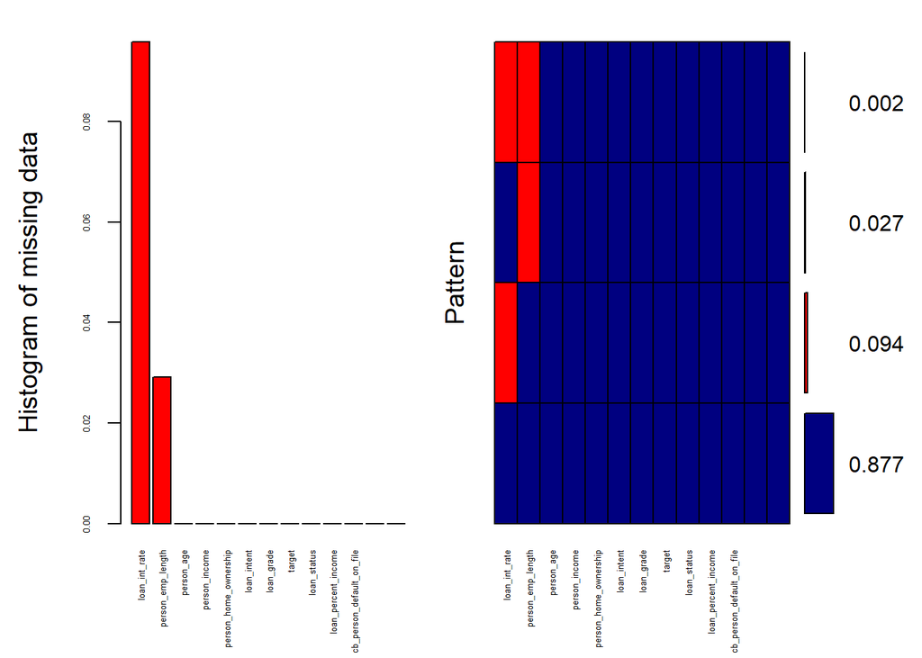

```
##
##  Variables sorted by number of missings:
##                        Variable      Count
##                   loan_int_rate 0.09585435
##               person_emp_length 0.02917306
##                      person_age 0.00000000
##                   person_income 0.00000000
##           person_home_ownership 0.00000000
##                     loan_intent 0.00000000
##                      loan_grade 0.00000000
##                          target 0.00000000
##                     loan_status 0.00000000
##             loan_percent_income 0.00000000
##       cb_person_default_on_file 0.00000000
##      cb_person_cred_hist_length 0.00000000
##  cb_person_cred_hist_length_cat 0.00000000
```

```r
aggr_plot <- aggr(train, col=c('navyblue','red'), numbers=TRUE, sortVars=TRUE,
                  labels=names(train), cex.axis=.4, gap=3,
                  ylab=c("Histogram of missing data","Pattern"))
```

Observamos que no están concentrados en casos concretos, que no hay ningún patrón y sólo tenemos missing en dos variables. Para ver el potencial de esta visión de estudio, hacemos gráfico de las dos variables que tienen missing para ver si encontramos algún patrón y éstas con el target, pero no es el caso, no hay patrón:

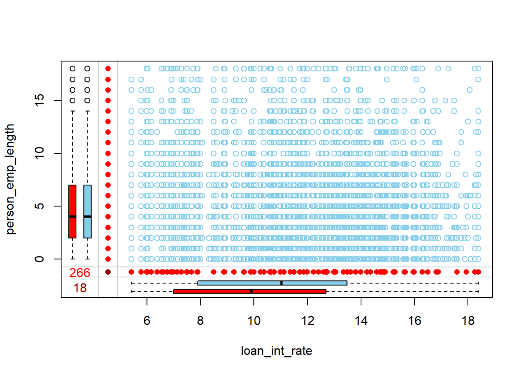

```r
train %>% select(loan_int_rate, person_emp_length) %>% marginplot()
```

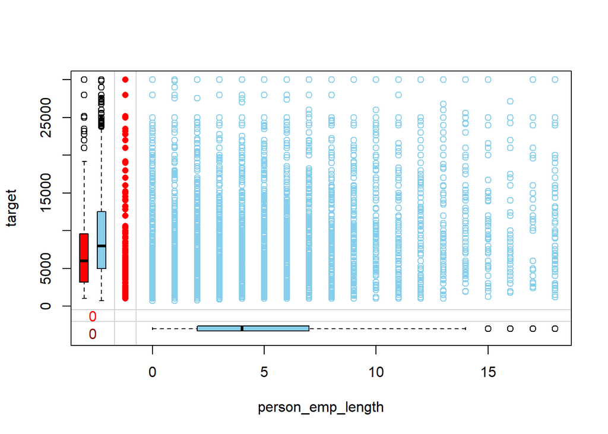

```r
train %>% select(person_emp_length, target) %>% marginplot()
```

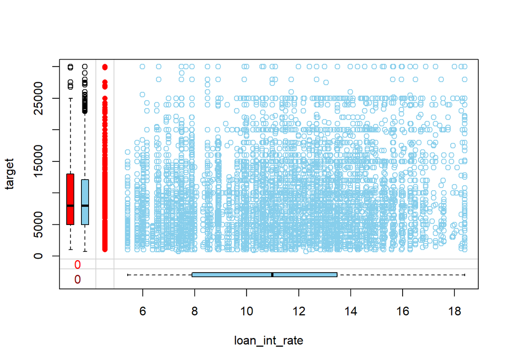

```r
train %>% select(loan_int_rate, target) %>% marginplot()
```

Generamos un dataframe con aquellos casos que tienen valores missing en cualquiera de los dos campos por si se quisiera ver en su conjunto la tabla, pero donde se ven las relaciones es en los gráficos anteriores.

```r
df_train_missing <-train %>%
        filter(is.na(person_emp_length) | is.na(loan_int_rate))
```

Como solución imputaremos el valor de la mediana a los missig siendo conscientes que no es la mejor solución. En aquellas variables que haya muchos missing puede modificar la distribución. En nuestro caso sí que podría afectar a la variable loan_int_rate que tiene un 9,8% de missing pero no en loan_int_rate, 2,9%.

Una opción de mejora en este caso es utilizar el paquete MICE de R, que dispone de las imputaciones clásicas de media y mediana y la posibilidad de imputar con métodos de regresión estocástica y multiple.

```r
train$person_emp_length[is.na(train$person_emp_length)] <-median(train$person_emp_length, na.rm=T)
train$loan_int_rate[is.na(train$loan_int_rate)] <-median(train$loan_int_rate, na.rm=T)

#train %>%   filter(loan_int_rate == NA & person_emp_length == NA)

#train %>%   filter(loan_int_rate == NA & person_emp_length == NA)
```

Comprobación rápida que ya no tenemos missing:

```r
apply(is.na(train),2,FUN="mean")*100
```

```
##                     person_age                  person_income
##                              0                              0
##          person_home_ownership              person_emp_length
##                              0                              0
##                    loan_intent                     loan_grade
##                              0                              0
##                         target                  loan_int_rate
##                              0                              0
##                    loan_status            loan_percent_income
##                              0                              0
##      cb_person_default_on_file     cb_person_cred_hist_length
##                              0                              0
## cb_person_cred_hist_length_cat
##                              0
```

## 4.5 Transformaciones de variables cuantitativas

**Importe del préstamo (loan_amnt/Target)**

Utilizamos la librería bestNormalize que nos da la opción de sacar multiples transformaciones y te indica cuál es la mejor.

```r
    (arcsinh_obj_tar <- arcsinh_x(train$target))
```

```
## Standardized asinh(x) Transformation with 9118 nonmissing obs.:
##  Relevant statistics:
##  - mean (before standardization) = 9.630751
##  - sd (before standardization) = 0.7147646
```

```r
    (boxcox_obj_tar <- boxcox(train$target))
```

```
## Standardized Box Cox Transformation with 9118 nonmissing obs.:
##  Estimated statistics:
##  - lambda = 0.2444405
##  - mean (before standardization) = 32.81431
##  - sd (before standardization) = 6.231206
```

```r
    (yeojohnson_obj_tar <- yeojohnson(train$target))
```

```
## Standardized Yeo-Johnson Transformation with 9118 nonmissing obs.:
##  Estimated statistics:
##  - lambda = 0.2443111
##  - mean (before standardization) = 32.7898
##  - sd (before standardization) = 6.223225
```

```r
    (orderNorm_obj_tar <- orderNorm(train$target))
```

```
## orderNorm Transformation with 9118 nonmissing obs and ties
##  - 509 unique values
##  - Original quantiles:
##    0%   25%   50%   75%  100%
##   725  5000  8000 12250 30000
```

```r
     (BNobject_tar <- bestNormalize(train$target))
```

```
## Best Normalizing transformation with 9118 Observations
##  Estimated Normality Statistics (Pearson P / df, lower => more normal):
##  - arcsinh(x): 14.3055
##  - Box-Cox: 13.431
##  - Center+scale: 19.4618
##  - Log_b(x+a): 14.3055
##  - orderNorm (ORQ): 9.9484
##  - sqrt(x + a): 13.7619
##  - Yeo-Johnson: 13.431
## Estimation method: Out-of-sample via CV with 10 folds and 5 repeats
##
## Based off these, bestNormalize chose:
## orderNorm Transformation with 9118 nonmissing obs and ties
##  - 509 unique values
##  - Original quantiles:
##    0%   25%   50%   75%  100%
##   725  5000  8000 12250 30000
```

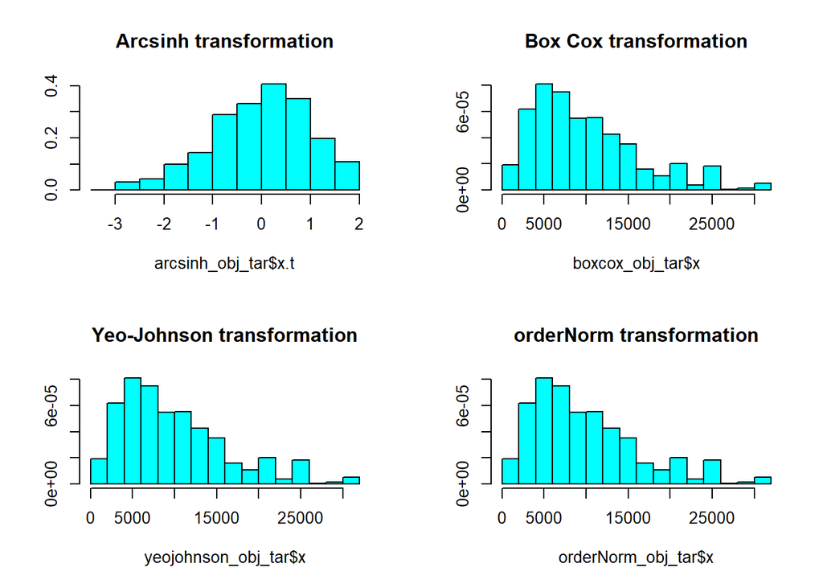

```r
    par(mfrow = c(2,2))
    MASS::truehist(arcsinh_obj_tar$x.t, main = "Arcsinh transformation", nbins = 12)
    MASS::truehist(boxcox_obj_tar$x, main = "Box Cox transformation", nbins = 12)
    MASS::truehist(yeojohnson_obj_tar$x, main = "Yeo-Johnson transformation", nbins = 12)
    MASS::truehist(orderNorm_obj_tar$x, main = "orderNorm transformation", nbins = 12)
```

En este caso la mejor es orderNorm (The Ordered Quantile technique), aunque la de Box Cox que era la que se barajaba en un principio es muy similar.

La función orderNorm hace una normalización de cuantil ordenado (ORQ) que utiliza un mapeo de rango de los datos observados a la distribución normal para garantizar una distribución transformada normal (si los lazos no están presentes). La normalización ORQ funciona de manera muy consistente a través de diferentes distribuciones, normalizando con éxito datos sesgados a la izquierda o a la derecha, datos multimodales.

Generamos una variable nueva con la transformación:

```r
train$target_tr <- orderNorm_obj_tar$x
```

**Edad (person_age)**

```r
    (arcsinh_obj_age <- arcsinh_x(train$person_age))
```

```
## Standardized asinh(x) Transformation with 9118 nonmissing obs.:
##  Relevant statistics:
##  - mean (before standardization) = 3.995994
##  - sd (before standardization) = 0.1948104
```

```r
    (boxcox_obj_age <- boxcox(train$person_age))
```

```
## Standardized Box Cox Transformation with 9118 nonmissing obs.:
##  Estimated statistics:
##  - lambda = -0.9999576
##  - mean (before standardization) = 0.9625832
##  - sd (before standardization) = 0.006664345
```

```r
    (yeojohnson_obj_age <- yeojohnson(train$person_age))
```

```
## Standardized Yeo-Johnson Transformation with 9118 nonmissing obs.:
##  Estimated statistics:
##  - lambda = -2.469734
##  - mean (before standardization) = 0.4047856
##  - sd (before standardization) = 4.428139e-05
```

```r
    (orderNorm_obj_age <- orderNorm(train$person_age))
```

```
## orderNorm Transformation with 9118 nonmissing obs and ties
##  - 31 unique values
##  - Original quantiles:
##   0%  25%  50%  75% 100%
##   20   23   26   30   50
```

```r
     (BNobject_age <- bestNormalize(train$person_age))
```

```
## Best Normalizing transformation with 9118 Observations
##  Estimated Normality Statistics (Pearson P / df, lower => more normal):
##  - arcsinh(x): 44.2077
##  - Box-Cox: 44.3392
##  - Center+scale: 43.8201
##  - Exp(x): 921.3669
##  - Log_b(x+a): 44.2077
##  - orderNorm (ORQ): 43.3828
##  - sqrt(x + a): 44.0381
##  - Yeo-Johnson: 44.8307
## Estimation method: Out-of-sample via CV with 10 folds and 5 repeats
##
## Based off these, bestNormalize chose:
## orderNorm Transformation with 9118 nonmissing obs and ties
##  - 31 unique values
##  - Original quantiles:
##   0%  25%  50%  75% 100%
##   20   23   26   30   50
```

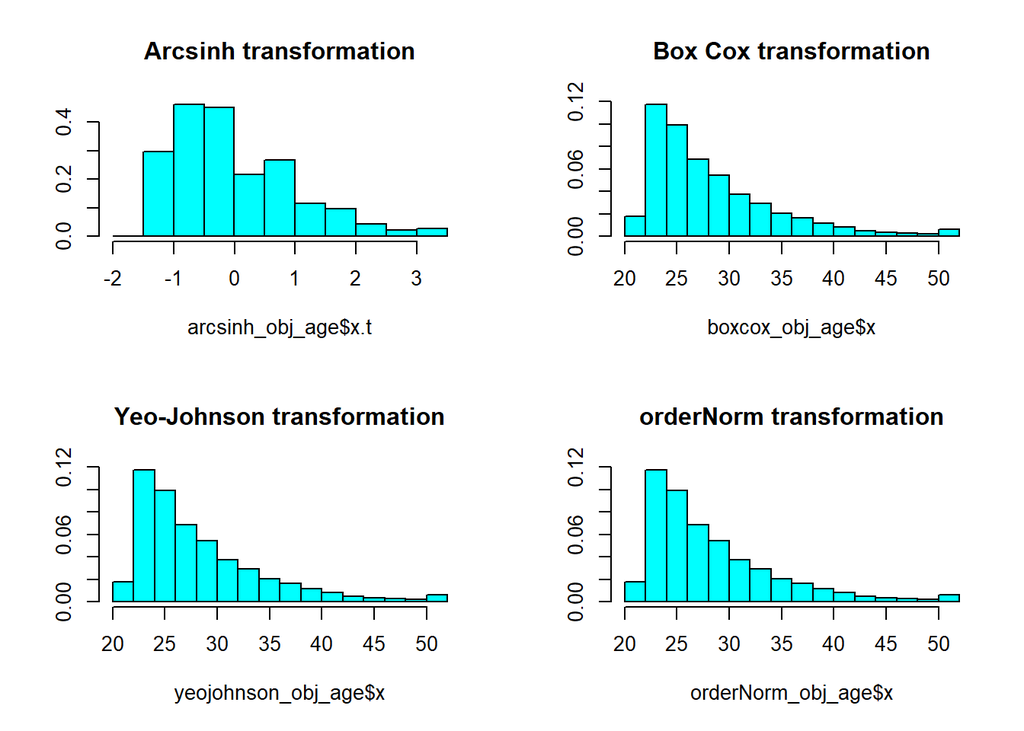

```r
    par(mfrow = c(2,2))
    MASS::truehist(arcsinh_obj_age$x.t, main = "Arcsinh transformation", nbins = 12)
    MASS::truehist(boxcox_obj_age$x, main = "Box Cox transformation", nbins = 12)
    MASS::truehist(yeojohnson_obj_age$x, main = "Yeo-Johnson transformation", nbins = 12)
    MASS::truehist(orderNorm_obj_age$x, main = "orderNorm transformation", nbins = 12)
```

En este caso la mejor es orderNorm (The Ordered Quantile technique).

Generamos una variable nueva con la transformación:

```r
train$person_age_tr <- orderNorm_obj_age$x
```

**Ingresos (person_income)**

```r
    (arcsinh_obj_in <- arcsinh_x(train$person_income))
```

```
## Standardized asinh(x) Transformation with 9118 nonmissing obs.:
##  Relevant statistics:
##  - mean (before standardization) = 11.61109
##  - sd (before standardization) = 0.5542995
```

```r
    (boxcox_obj_in <- boxcox(train$person_income))
```

```
## Standardized Box Cox Transformation with 9118 nonmissing obs.:
##  Estimated statistics:
##  - lambda = 0.05756966
##  - mean (before standardization) = 15.21337
##  - sd (before standardization) = 1.038359
```

```r
    (yeojohnson_obj_in <- yeojohnson(train$person_income))
```

```
## Standardized Yeo-Johnson Transformation with 9118 nonmissing obs.:
##  Estimated statistics:
##  - lambda = 0.0575431
##  - mean (before standardization) = 15.21097
##  - sd (before standardization) = 1.038037
```

```r
    (orderNorm_obj_in <- orderNorm(train$person_income))
```

```
## orderNorm Transformation with 9118 nonmissing obs and ties
##  - 1680 unique values
##  - Original quantiles:
##       0%      25%      50%      75%     100%
##   4000.0  38400.0  55000.0  79527.0 224292.1
```

```r
     (BNobject_in <- bestNormalize(train$person_income))
```

```
## Best Normalizing transformation with 9118 Observations
##  Estimated Normality Statistics (Pearson P / df, lower => more normal):
##  - arcsinh(x): 2.6839
##  - Box-Cox: 2.7288
##  - Center+scale: 10.7932
##  - Log_b(x+a): 2.6839
##  - orderNorm (ORQ): 1.7788
##  - sqrt(x + a): 4.5933
##  - Yeo-Johnson: 2.7321
## Estimation method: Out-of-sample via CV with 10 folds and 5 repeats
##
## Based off these, bestNormalize chose:
## orderNorm Transformation with 9118 nonmissing obs and ties
##  - 1680 unique values
##  - Original quantiles:
##       0%      25%      50%      75%     100%
##   4000.0  38400.0  55000.0  79527.0 224292.1
```

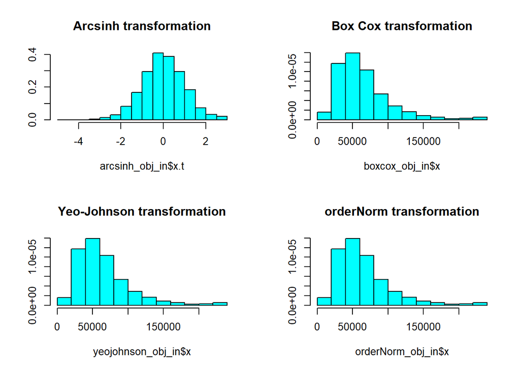

```r
    par(mfrow = c(2,2))
    MASS::truehist(arcsinh_obj_in$x.t, main = "Arcsinh transformation", nbins = 12)
    MASS::truehist(boxcox_obj_in$x, main = "Box Cox transformation", nbins = 12)
    MASS::truehist(yeojohnson_obj_in$x, main = "Yeo-Johnson transformation", nbins = 12)
    MASS::truehist(orderNorm_obj_in$x, main = "orderNorm transformation", nbins = 12)
```

En este caso la mejor es orderNorm (The Ordered Quantile technique). Generamos una variable nueva con la transformación:

```r
train$person_income_tr <- orderNorm_obj_in$x
```

**Tiempo trabajado (person_emp_length)**

```r
    (arcsinh_obj_len <- arcsinh_x(train$person_emp_length))
```

```
## Standardized asinh(x) Transformation with 9118 nonmissing obs.:
##  Relevant statistics:
##  - mean (before standardization) = 1.901531
##  - sd (before standardization) = 0.9673668
```

```r
    (yeojohnson_obj_len <- yeojohnson(train$person_emp_length))
```

```
## Standardized Yeo-Johnson Transformation with 9118 nonmissing obs.:
##  Estimated statistics:
##  - lambda = 0.2923454
##  - mean (before standardization) = 1.996252
##  - sd (before standardization) = 1.163774
```

```r
    (orderNorm_obj_len <- orderNorm(train$person_emp_length))
```

```
## orderNorm Transformation with 9118 nonmissing obs and ties
##  - 19 unique values
##  - Original quantiles:
##   0%  25%  50%  75% 100%
##    0    2    4    7   18
```

```r
    #(boxcox_obj <- boxcox(train$person_emp_length))
    (BNobject_len <- bestNormalize(train$person_emp_length))
```

```
## Best Normalizing transformation with 9118 Observations
##  Estimated Normality Statistics (Pearson P / df, lower => more normal):
##  - arcsinh(x): 60.8951
##  - Center+scale: 61.4467
##  - Exp(x): 846.1987
##  - Log_b(x+a): 80.5094
##  - orderNorm (ORQ): 60.7212
##  - sqrt(x + a): 59.8275
##  - Yeo-Johnson: 59.9942
## Estimation method: Out-of-sample via CV with 10 folds and 5 repeats
##
## Based off these, bestNormalize chose:
## Standardized sqrt(x + a) Transformation with 9118 nonmissing obs.:
##  Relevant statistics:
##  - a = 0
##  - mean (before standardization) = 1.922073
##  - sd (before standardization) = 1.022388
```

```r
    (sqrt_x_object_len <- sqrt_x(train$person_emp_length))
```

```
## Standardized sqrt(x + a) Transformation with 9118 nonmissing obs.:
##  Relevant statistics:
##  - a = 0
##  - mean (before standardization) = 1.922073
##  - sd (before standardization) = 1.022388
```

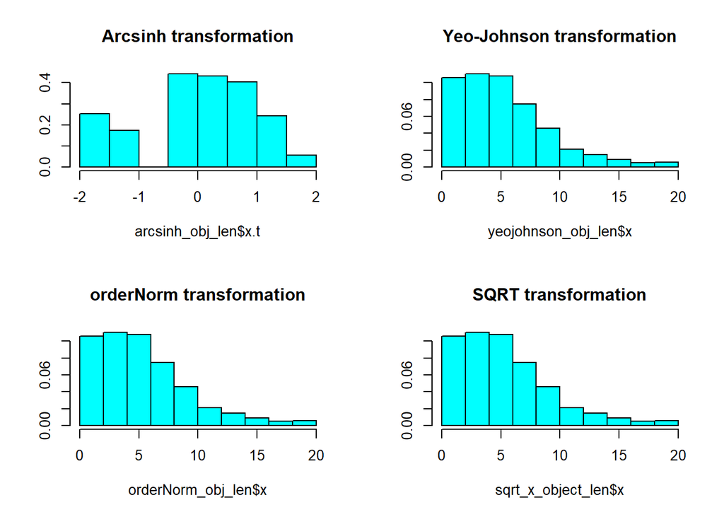

```r
    par(mfrow = c(2,2))
    MASS::truehist(arcsinh_obj_len$x.t, main = "Arcsinh transformation", nbins = 12)
    #MASS::truehist(boxcox_obj$x, main = "Box Cox transformation", nbins = 12)
    MASS::truehist(yeojohnson_obj_len$x, main = "Yeo-Johnson transformation", nbins = 12)
    MASS::truehist(orderNorm_obj_len$x, main = "orderNorm transformation", nbins = 12)
    MASS::truehist(sqrt_x_object_len$x, main = "SQRT transformation", nbins = 12)
```

```r
    #str(train$person_emp_length)
```

En este caso la mejor es la raiz cuadrada. Generamos una variable nueva con la transformación:

```r
train$person_emp_length_tr <- sqrt_x_object_len$x
```

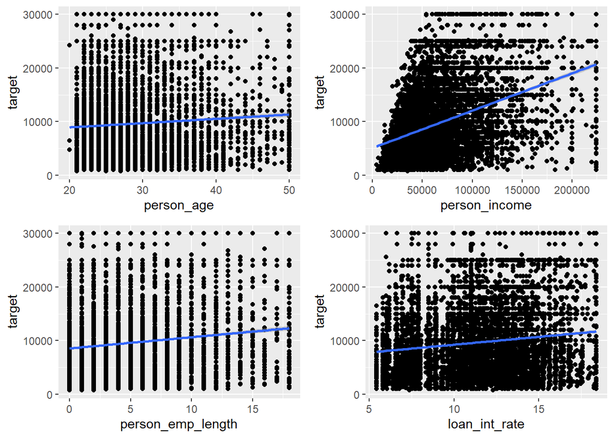

```r
bi1=ggplot(train, aes(x=person_age, y=target)) +
  geom_point() +
  stat_smooth(method=lm)

bi2=ggplot(train, aes(x=person_income, y=target)) +
  geom_point() +
  stat_smooth(method=lm)

bi3=ggplot(train, aes(x=person_emp_length, y=target)) +
  geom_point() +
  stat_smooth(method=lm)

bi4=ggplot(train, aes(x=loan_int_rate, y=target)) +
  geom_point() +
  stat_smooth(method=lm)

plot_grid(bi1, bi2,bi3,bi4)
```

## 4.6 Correlaciones

Calculamos las correlaciones para las variables numéricas. Este paso se podría haber hecho también en la fase previa a hacer los cambios en las variables, es decir antes de las imputaciones de percentiles, de transfomraciones, de hecho es recomendable, pero cuando hay datos de missing se recomienda también después dada la sensibilidad de estos cálculos cuando existen missing.

Las correlaciones más habituales son las de Pearson, Kendall y Sperman.

```r
corr_matrix <- train %>% select_if(is.numeric) %>%
  select(-c(loan_status,loan_percent_income)) %>%
  cor(method="pearson", use="pairwise.complete.obs")

library('corrplot')
```

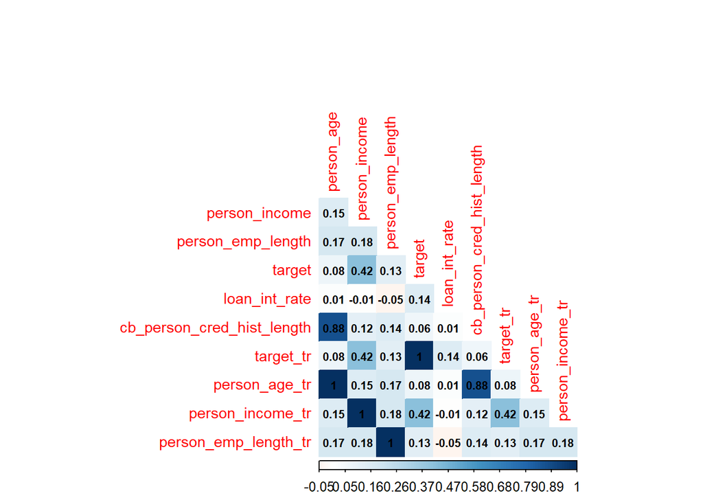

```r
# Gráfico de correlación con color y correlación MIC
corrplot(corr_matrix,
         method="color",
         type="lower",
         number.cex=0.7,
         # Agregar coeficiente de correlación
         addCoef.col = "black",
         tl.col="red",
         tl.srt=90,
         tl.cex = 0.9,
         diag=FALSE,
         is.corr = F
)
```

Se obserava las correlaciones de valor 1 de las variables transformadas con las de su origen, también destaca la edad y el lapso de tiempo desde que pediste el último crédito, lógica y además esta última variable la hemos discretizado por lo que no se usará la numérica y por otro lado la más interesante nuestra variable target, importe de préstamo, con los ingresos de la persona que le dán el crédito.

# 5 Regresión

## 5.1 Regresión simple

Primero haremos una regresión simple con la variable de mayor correlación con la variable dependiente (target_tr ~ ingresos_tr):

```r
lm_fit <- lm(target_tr~person_income_tr, data=train)
summary(lm_fit)
```

```
##
## Call:
## lm(formula = target_tr ~ person_income_tr, data = train)
##
## Residuals:
##    Min     1Q Median     3Q    Max
## -19693  -3969  -1022   3064  21144
##
## Coefficients:
##                   Estimate Std. Error t value Pr(>|t|)
## (Intercept)      5.102e+03  1.176e+02   43.38   <2e-16 ***
## person_income_tr 6.951e-02  1.581e-03   43.98   <2e-16 ***
## ---
## Signif. codes:  0 '***' 0.001 '**' 0.01 '*' 0.05 '.' 0.1 ' ' 1
##
## Residual standard error: 5685 on 9116 degrees of freedom
## Multiple R-squared:  0.175,  Adjusted R-squared:  0.1749
## F-statistic:  1934 on 1 and 9116 DF,  p-value: < 2.2e-16
```

El p-valor del modelo es significativamente bajo, 2.2e-16, por lo que se puede aceptar que el modelo no es por azar. Para los parámetros de la regresión lineal, tanto el de la constante como el de ingresos tienen p-valores muy bajos también por lo que podemos rechazar la hipótesis nula. En cuanto al R cuadrado explica el 17,51% de la variabilidad del importe del prestamo, cifra muy muy baja.

Y el el error estándar residual (Residual standard error) es de 5.685 este valor cuanto más pequeño mejor, el coeficiente constante es 5.102e+03 y el de person_income_tr, 6.951e-02

La interpretación de los coeficientes al ser muy bajos es difícil de interpretar, por lo que pondré otro modelo fitctio para explicar:

importe_prestamo= 47,60 + 3,01 × ingresos

En este ejemplo los coeficientes de regresión son 47,60 para la constante y 3,01 para ingresos y la interpretación es cuando aumentamos en una unidad en los ingresos, el importe de préstamo aumenta en 3,01 unidades.

Es decir, los coeficientes de una regresión simple se interpretan como el cambio en la variable dependiente (Y) por unidad de cambio en la variable independiente (X) mientras se mantiene constante el resto de las variables independientes. El coeficiente de la variable independiente se llama el “pendiente” y el coeficiente constante se llama el “intercepto”.

## 5.2 Regresión multiple

### 5.2.1 Métodos de selección de variables

Para este apartado nos basaremos fielmente en el trabajo elaborado por Victor Aceña en noviembre de 2021.

Usaremos el método Subset que consiste en generar todas las combinaciones de variables posibles y quedarse con el “mejor” subconjunto de ellas. Considerando mejor, el que obtenga una puntuación superior para alguna métrica de evaluación definida previamente.

Como se observa a continuación, para implementar este método se utiliza la función regsubsets de la librería leaps.

```r
regfit_full <- leaps::regsubsets(target_tr~ person_age_tr+ person_income_tr+
                                   person_emp_length_tr+loan_int_rate+loan_intent
                                 +cb_person_cred_hist_length_cat+ person_home_ownership,
                                 data=train,nvmax=5)
```

```
## Reordering variables and trying again:
```

```r
reg_sum <- summary(regfit_full)
reg_sum
```

```
## Subset selection object
## Call: regsubsets.formula(target_tr ~ person_age_tr + person_income_tr +
##     person_emp_length_tr + loan_int_rate + loan_intent + cb_person_cred_hist_length_cat +
##     person_home_ownership, data = train, nvmax = 5)
## 14 Variables  (and intercept)
##                                         Forced in Forced out
## person_age_tr                               FALSE      FALSE
## person_income_tr                            FALSE      FALSE
## person_emp_length_tr                        FALSE      FALSE
## loan_int_rate                               FALSE      FALSE
## loan_intentEDUCATION                        FALSE      FALSE
## loan_intentHOMEIMPROVEMENT                  FALSE      FALSE
## loan_intentMEDICAL                          FALSE      FALSE
## loan_intentPERSONAL                         FALSE      FALSE
## loan_intentVENTURE                          FALSE      FALSE
## cb_person_cred_hist_length_cat5-10          FALSE      FALSE
## cb_person_cred_hist_length_catMás de 10     FALSE      FALSE
## person_home_ownershipOWN                    FALSE      FALSE
## person_home_ownershipRENT                   FALSE      FALSE
## person_home_ownershipOTHER                  FALSE      FALSE
## 1 subsets of each size up to 6
## Selection Algorithm: exhaustive
##          person_age_tr person_income_tr person_emp_length_tr loan_int_rate
## 1  ( 1 ) " "           "*"              " "                  " "
## 2  ( 1 ) " "           "*"              " "                  "*"
## 3  ( 1 ) " "           "*"              "*"                  "*"
## 4  ( 1 ) " "           "*"              "*"                  "*"
## 5  ( 1 ) " "           "*"              "*"                  "*"
## 6  ( 1 ) " "           "*"              "*"                  "*"
##          loan_intentEDUCATION loan_intentHOMEIMPROVEMENT loan_intentMEDICAL
## 1  ( 1 ) " "                  " "                        " "
## 2  ( 1 ) " "                  " "                        " "
## 3  ( 1 ) " "                  " "                        " "
## 4  ( 1 ) " "                  " "                        " "
## 5  ( 1 ) "*"                  " "                        " "
## 6  ( 1 ) "*"                  " "                        " "
##          loan_intentPERSONAL loan_intentVENTURE
## 1  ( 1 ) " "                 " "
## 2  ( 1 ) " "                 " "
## 3  ( 1 ) " "                 " "
```

[output cut: 9 more lines]

```
## 6  ( 1 ) " "
##          cb_person_cred_hist_length_catMás de 10 person_home_ownershipOTHER
## 1  ( 1 ) " "                                     " "
## 2  ( 1 ) " "                                     " "
## 3  ( 1 ) " "                                     " "
## 4  ( 1 ) " "                                     " "
## 5  ( 1 ) " "                                     " "
## 6  ( 1 ) " "                                     " "
##          person_home_ownershipOWN person_home_ownershipRENT
## 1  ( 1 ) " "                      " "
## 2  ( 1 ) " "                      " "
## 3  ( 1 ) " "                      " "
## 4  ( 1 ) " "                      "*"
## 5  ( 1 ) " "                      "*"
## 6  ( 1 ) "*"                      "*"
```

Para poder evaluar los modelos, podemos consultar los vectores de métricas almacenados mediante summary, por ejemplo el R cuadrado ajustado, el criterio de información de Akaike,Cp (AIC) y criterio de información bayesiano, BIC. Estos dos últimos al ser medidas relacionadas con los errores, cuanto más baja comparado con otro modelo, mejor será el modelo.

```r
reg_sum$adjr2
```

```
## [1] 0.1749392 0.1954912 0.1996183 0.1999185 0.2002102 0.2002749
```

```r
reg_sum$bic
```

```
## [1] -1736.139 -1958.025 -1996.802 -1992.105 -1987.313 -1979.933
```

Para evaluarlo de una manera visual, el paquete tiene una función plot incorporada que nos indica la mejor combinación probada en función de las distintas métricas disponibles.

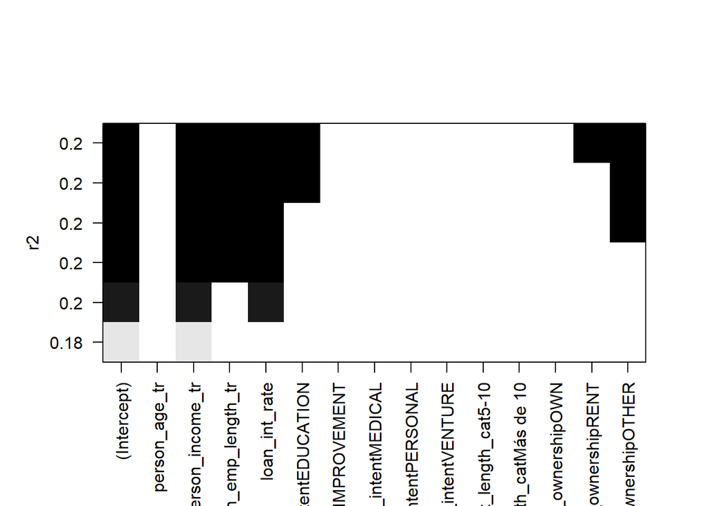

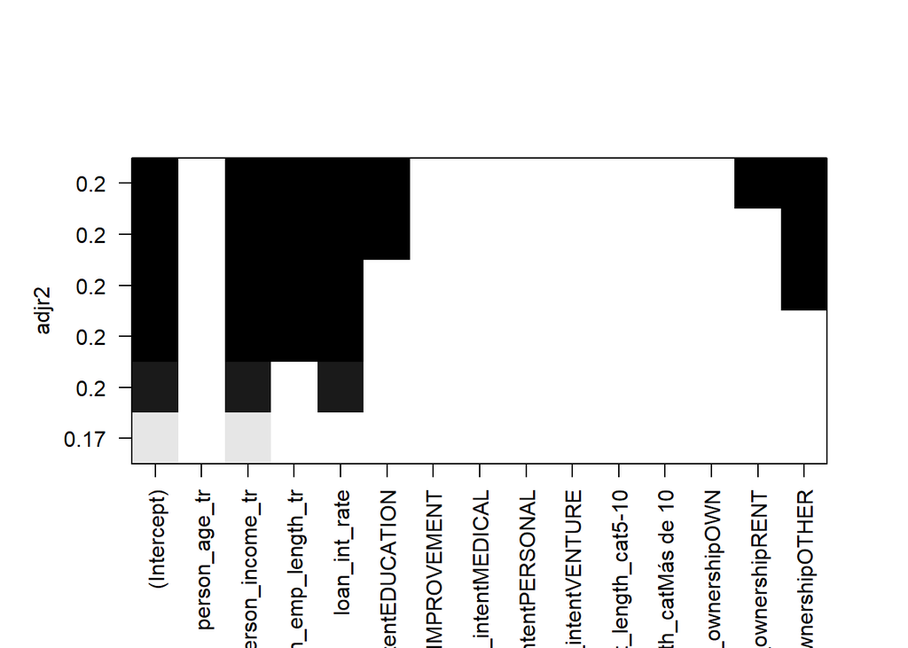

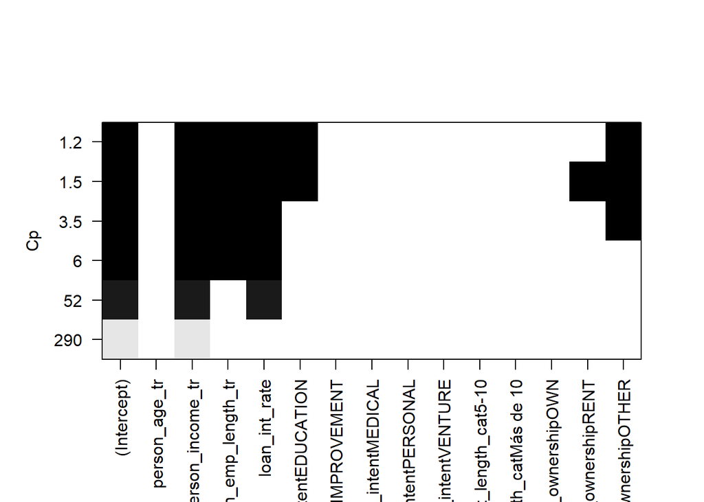

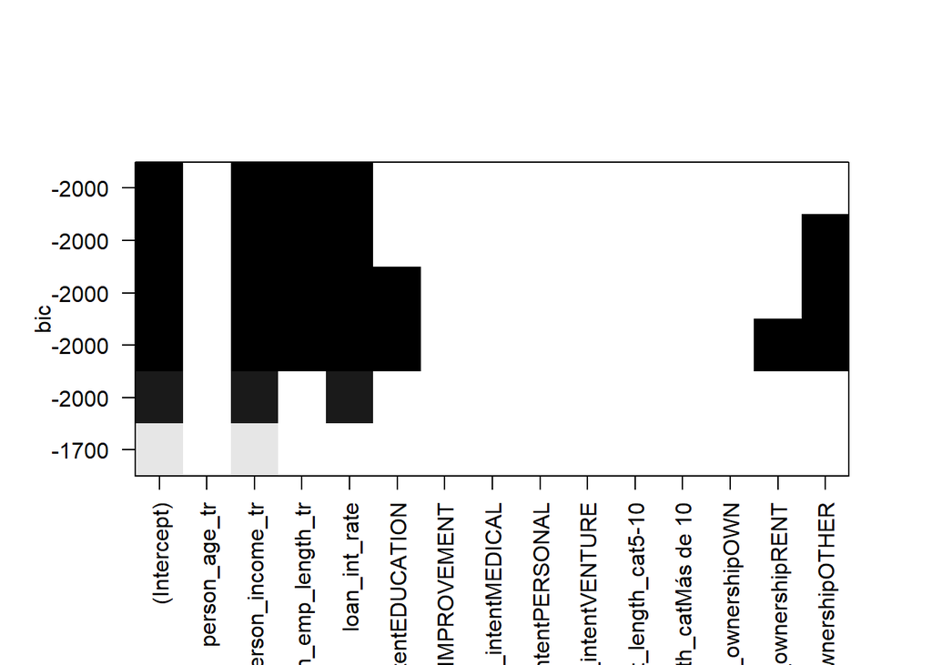

```r
for (metric in c("r2", "adjr2", "Cp", "bic")){plot(regfit_full, scale=metric)}
```

Una vez se haya seleccionado uno de los modelos, se pueden obtener los coeficientes para cada una de las variables con la instrucción coef.

```r
coef(regfit_full, 1)
```

```
##      (Intercept) person_income_tr
##     5.102370e+03     6.951087e-02
```

Existen otros métodos como:

Forward Stepwise: este método parte de un conjunto de variables vacío, de manera que este se incrementa con la variable que más mejora el modelo para la métrica seleccionada. Se incluye una variable a cada paso, hasta que se llega al número seleccionado o el modelo no mejora más.

Backward Stepwise: al contaratio que el forward se parte del conjunto de todas las variables, de manera que este se disminuye con la variable que más mejora el modelo para la métrica seleccionada. Se elimina una variable a cada paso, hasta que se llega al número seleccionado o el modelo no mejora más

Y luego existe el método clasico de ir partiendo de todas las variables e ir sacando y metiendo en función de los contrastes de hipótesis de los parámetros y del conocimiento de la materia a estuadiar.

Siempre es aconsejable barajar varios metodos y contrastarlos y hacer muchas pruebas, hoy en día es más sencillo dado que las máquinas pueden soportarlo.

Gráficos por número de variables, R ajustado y BIC:

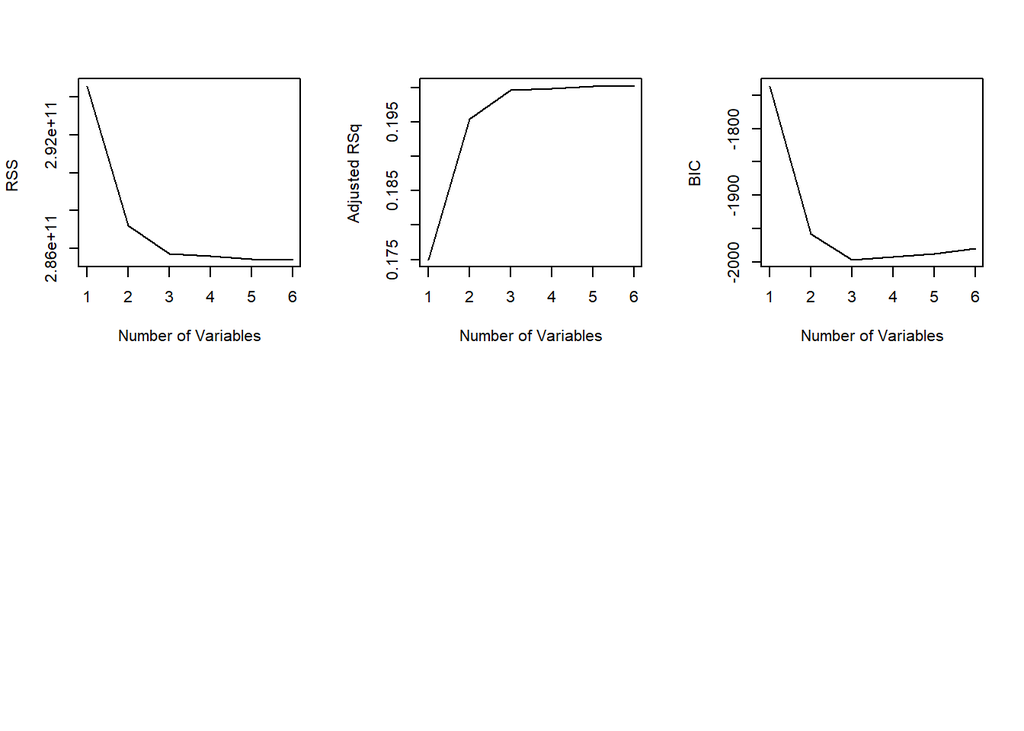

```r
par ( mfrow =c(2 ,3) )
plot(reg_sum$rss , xlab ="Number of Variables", ylab ="RSS ",type ="l")
plot(reg_sum$adjr2 ,xlab ="Number of Variables",ylab ="Adjusted RSq", type ="l")
plot(reg_sum$bic ,xlab ="Number of Variables",ylab ="BIC", type ="l")
```

Regresión con las variables seleccionadas:

```r
summary(modelo_final<-lm(target_tr~person_income_tr, train))
```

```
##
## Call:
## lm(formula = target_tr ~ person_income_tr, data = train)
##
## Residuals:
##    Min     1Q Median     3Q    Max
## -19693  -3969  -1022   3064  21144
##
## Coefficients:
##                   Estimate Std. Error t value Pr(>|t|)
## (Intercept)      5.102e+03  1.176e+02   43.38   <2e-16 ***
## person_income_tr 6.951e-02  1.581e-03   43.98   <2e-16 ***
## ---
## Signif. codes:  0 '***' 0.001 '**' 0.01 '*' 0.05 '.' 0.1 ' ' 1
##
## Residual standard error: 5685 on 9116 degrees of freedom
## Multiple R-squared:  0.175,  Adjusted R-squared:  0.1749
## F-statistic:  1934 on 1 and 9116 DF,  p-value: < 2.2e-16
```